[Home](https://canholyavkin.github.io) - [Other Posts](https://canholyavkin.github.io/#blog) - Contact

# JCVI-syn3.0: Minimal Genom Projesi

İlk Minimal Sentetik Bakteri

En az kaç parça ile bir otomobil üretebilirsiniz? Veya bir telefon? **Peki canlı bir hücre yaratmak için ne kadar genetik bilgiye ihtiyacınız var?**

Sentetik biyolojinin belki de en ateşli sorusunun cevabı geçtiğimiz yıl J. Craig Venter Enstitüsü’nün yayınladığı çalışma ile verildi. Gerçekleştirilen çalışma, hayatta kalmanın asgari gereksinimlerini öğrenmemizi sağlıyor. Her şeyin ötesinde bildiğimiz anlamda yaşamın tanımını daha iyi yapmamızı sağlayacak önemli bilgiler sunuyor.

[J. Craig Venter Enstitüsü](http://jcvi.org/) (JCVI) ve [Synthetic Genomics](https://www.syntheticgenomics.com/) kuruluşlarının uzun soluklu projesine ait ilk veriler, bir hücrenin hayatını sürdürebilmesi için gerekli minimum gen sayısının 473 olduğunu gösteriyor. **Bu hücre, daha şimdiden bilinen tüm canlı türler arasında en küçük genoma sahip olma rekoruna da sahip olmuş durumda.** Tasarımı ve üretimi tamamen insanlar tarafından gerçekleştirilen bu minimal hücre hattının adı da **JCVI-syn3.0**.

# İlk Deneme: JCVI-syn1.0

JCVI-syn3.0, enstitünün sentetik biyoloji alanındaki ilk başarısı da değil. 2003 yılında, ilk defa bakteri enfekte edebilen özellikte bir virüs (bakteriyofaj) laboratuvar ortamında başarıyla sentezlenmişti. [^1] 1 2008 yılına gelindiğinde ise araştırma grubu, bu sefer bir bakteriyel genomu tamamen hücre dışında kimyasal olarak üretmeyi başarmıştı. [^2] 2 Ancak o zamanlarda bunu canlı bir hücre içinde aktif olarak kullanmamışlardı.

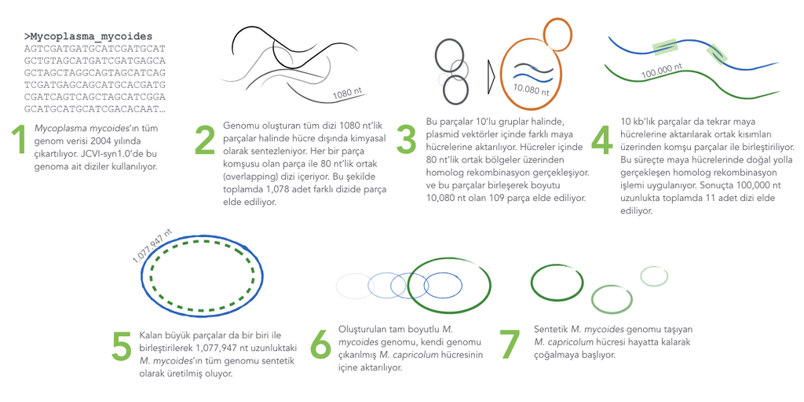

JCVI-syn1.0 adı verilen ve hücre dışında üretilmiş sentetik genoma sahip olan bu ilk hücrenin başarıyla hayatta kalması büyük ses getirdi. Bu yeni sentetik genom, 1 milyon bazdan fazla nükleotit ve 900’den fazla gene sahipti. Ancak minimal hücre hattını oluşturmak için hâla büyük sayılıyordu.

Evrimsel süreçte milyarlarca yılda oluşan bir bakteriyel genom, fotokopi makinası gibi hücre dışında çoğaltılmış; ardından tekrar hücre içine konulmuş ve hücreye hayat vermişti. Kil tablete yazılmış kayıp bir dili son 20 yıldır okuyabiliyordu, şimdi ise kopyalamayı başarmıştık. Ancak yazıtların içeriği hakkında hala çok az fikrimiz vardı.

Bu sebeple çalışma, bir sonraki önemli sorunun cevabını aramaya başladı: **Yaşamın temelini oluşturan genler, bu genomun neresinde?**

# Kontrollü Küçülme: JCVI-syn3.0

İlk sentetik hücrenin üretiminden sonra, aynı araştırma grubu, ilk versiyon üzerinde önemli değişikliklere gitmeye karar verdi. **Yeni amaç, ilk genom üzerinde yaşam için elzem olmayan genlerin tek tek elenip, hayatta kalmayı sağlayacak asgari gen sayısını bulmaktı.** Bu çalışmaların sonuçları, ilk çalışmadan tam 6 yıl sonra yayınlandı.[^4] Yeni hücre hattına da yeni versiyonu ifade eden **JCVI-syn3.0** adı verildi.

Sentetik hücrenin son versiyonu olan JCVI-syn3.0, kardeşine göre genomik olarak gerçekten daha küçüktü. İlk versiyondaki genomun yarısı, son tasarımdan çıkarıldı. 1 Milyon nükleotitten sadece 500.000’i; 900 genden ise 473 tanesi son tasarımda korundu. Bu küçük yapısı ile JCVI-syn3.0, (sentetik de olsa) bilinen en küçük genoma sahip organizması ünvanını da almış oldu.

JCVI-syn3.0’nın genomunda yer alan bu 473 genin hepsinin bu hücrenin yaşaması için şart olduğu artık biliyor. **İşin ilgiç kısmı *M. mycoides* genomik alanda sıklıkla çalışılan bir tür olmasına rağmen, bu genlerin 79 tanesinin hücredeki fonksiyonu hakkında bilgimiz dahi yok.**

JCVI-syn3.0, genom içi organizasyonu da tamamen insanlar tarafından hazırlanan ilk sentetik hücre. Genom içerisinde yer alan tüm genlerin konumları, araştırmacılar tarafından tek tek belirlenerek yerleştirilmiş. Bu özelliği açısından da diğer “doğal” hücrelerden ayrılıyor. **Evrimsel sürecte oluşan “doğal” genomlarda benzer fonksiyona sahip genler, genomun farklı yerlerine dağılabilirken, JCVI-syn3.0’te yakın görevdeki genler aynı segmentte yer alacak şekilde tasarlanmış.**

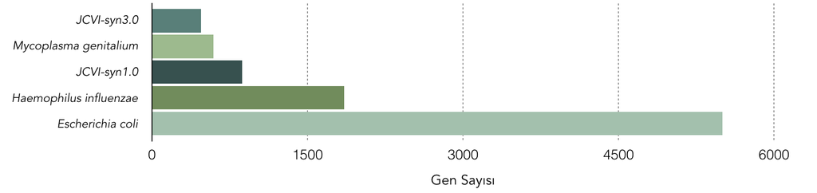

Bu düzenli organizasyonun, gelecek sentetik hücreler üzerinde değişiklikler yapılmasını da kolaylaştıracak. Yeni fonksiyon kazandıracak genler, modül benzeri kolaylıkla eklenip çıkarılabilecek. Tıpkı bir bilgisayarda ekran kartı değiştirilebiliyor gibi genetik özellikler de değiştirilebilecek. Tüm bu uygulamalar ile metabolik mühendisliğin uygulama alanlarının artması öngörülüyor.

Benzer şekilde hücreler üzerinde değişiklikler yapılarak ihtiyaca yönelik tasarlanması hâli hazırda yıllardır yapılmakta. Örneğin S. cerevisiaea (ekmek mayası)’nda genetik müdahaleler ile hücre içinde sıtma ilaçlarının üretilmesi mümkün hale geldi.[^5] JCVI-syn3.0’ın sıfırdan oluşturulan genomu ile benzeri yeni ürünlerin üretilme olasılıklarını çok daha artabilecek.

# Endişeler

Genomik açıdan tamamen insan ürünü olan JCVI-syn3.0 sağladığı bilimsel katkıları göz ardı edilemez. Ancak yanı sıra birçok felsefi konuyu ve endişeyi de beraberinde getiriyor. **Yaşam Nedir? Sınırı Nerede Başlar? gibi sorulara ek olarak, üretilen sentetik hücrelerin biyoterörizm gibi tehlikeli alanlarda da kullanılabilecek olması önemli soru işaretleri oluşturuyor.**

Bu amaçla JCVI’deki araştırma grubu, biyoetikçiler, telif, yasa uzmanları ve bireyler ile birlikte çalışmalar yürütüyor. Bu çalışmalarda sentetik genomik alanının toplumsal etkileri hakkında tartışmayı ve karşılıklı endişelerin anlaşılması amaçlanıyor. JCVI’nin araştırma ekibi, bu çalışmalarda, Massachusetts Teknoloji Enstitüsü (MIT) ile birlikte, Alfred P. Sloan Vakfı tarafından sağlanan 20 aylık bir araştırma için finansman sağlamış durumda. Bu gelişmekte olan teknolojinin riskleri ve yararları ile biyoterörizm de dahil olmak üzere kötüye kullanımı önlemeye yönelik muhtemel önlemleri araştırılıyor.

**JCVI-syn3.0’un bu minimal genomu, gelecek genetik çalışmalarında farklı amaçlara yönelik yeni hücrelerin geliştirilmesinde şablon görevi ile büyük öneme sahip. Her şeyin ötesinde, bilinen anlamıyla “yaşamın” sınırlarını ile ile ilgili bilimsel ve felsefi katkılarını da zamanla göreceğiz.**

# Kısa Notlar:

- JCVI-syn1.0 genomu içerisinde çalışmayı gerçekleştiren 46 araştırmacının adları da genom içerisine eklendi. Bunun için alfabetik kodlar, 4’lü DNA koduna çevrildi. Araştırmacılardan Dr. Craig Venter’ın adı, genom içerisine “TTA ACT AGC TAA TGT CGT GCA ATT GGA GTA GAG AAC ACA GAA CGA TTA ACT AGC TAA” kodu ile eklendi. Bu adların yanı sıra, 3 alıntı da DNA kodlarına çevrilerek genom içerisine eklendi.
- “To live, to err, to fall, to triumph, to recreate life out of life.” – James Joyce
- “See things not as they are, but as they might be.”- “American Prometheus” adlı kitaptan alıntı
- “I cannot build, I cannot understand.” – Richard Feynman
- JCVI-syn3.0 genom verileri Genbank veritabanında CP014940 kayıt numarası (accession number) ile tutuluyor. Dilerseniz bu diziye doğrudan ulaşabilirsiniz.
- JCVI-syn1.0 genom verilerine ise CP002027 kayıt numarası ile ulaşabilirsiniz.
- Çalışmanın etik kısmı ile ile ilgili çeşitli atölye çalışmaları ve halka açık oturumlardan sonra grup, Ekim 2007’de alan uzmanlarının ve araştırmacılarının [seçeneklerini özetleyen bir rapor](http://www.jcvi.org/cms/press/press-releases/full-text/article/new-policy-report-outlines-options-for-governance-of-synthetic-genomics/) yayınladı.
[^1]: Smith, H., Hutchison, C., Pfannkoch, C. & Venter, J. Generating a synthetic genome by whole genome assembly: phiX174 bacteriophage from synthetic oligonucleotides. Proc Natl Acad Sci U S A 100, 15440–5 (2003).
[^2]: Gibson, D. et al. Complete chemical synthesis, assembly, and cloning of a Mycoplasma genitalium genome. Science 319, 1215–20 (2008).
[^3]: Gibson, D. et al. Creation of a bacterial cell controlled by a chemically synthesized genome. Science 329, 52–6 (2010).
[^4]: Hutchison, C. et al. Design and synthesis of a minimal bacterial genome. Science 351, aad6253 (2016)
[^5]: Ro, D. et al. Production of the antimalarial drug precursor artemisinic acid in engineered yeast. Nature 440, 940–3 (2006)

**Can Holyavkin**

E-posta | [Linkedin](https://www.linkedin.com/in/can-holyavkin/) | [Twitter](https://twitter.com/CanHolyavkin)